# Pekan 2 — Data Visualization

Hands-on R: Visualisasi Data Sederhana

BPJS Corporate University

Satu hands on untuk Day 1 dan Day 2 Pekan 2. Data latihan bersama dipakai untuk studi kasus fraud, cross selling, risk scoring, dan penetapan premi.

Hands on

Dataset visualisasi (CSV) · 55 KB

Latihan bersama

01 · Fraud (CSV) · 22 KB02 · Cross Selling (CSV) · 26 KB03 · Risk Scoring (CSV) · 24 KB04 · Penetapan Premi (CSV) · 30 KBLembar latihan (PDF) · 288 KB

# Tujuan Pembelajaran

Setelah menyelesaikan hands-on ini, peserta diharapkan mampu:

1. memahami tujuan data visualization;
2. mengenali tipe variabel yang akan divisualisasikan;
3. menggunakan `dplyr` untuk menyiapkan data;
4. menggunakan `ggplot2` untuk membuat grafik;
5. memilih grafik berdasarkan pertanyaan analisis;
6. membuat visualisasi univariate dan bivariate;
7. membandingkan kelompok dengan `color`, `fill`, dan `facet`;
8. membaca pola dari grafik;
9. menulis interpretasi singkat yang menjawab pertanyaan klien;
10. memilih strategi visualisasi yang sesuai dengan pola soal PAI;
11. mengenali penggunaan line chart, pie chart, density plot, dan area chart secara tepat;
12. memahami parameter `ggplot2` yang umum digunakan untuk memperjelas visualisasi;
13. menjelaskan tujuan visualisasi: eksplorasi, analisis, dan komunikasi;
14. menerapkan prinsip clarity, accuracy, dan readability serta mengenali grafik yang menyesatkan;
15. membedakan aesthetic mapping (di dalam `aes()`) dan setting (di luar `aes()`);
16. menyiapkan data dengan `filter()`, `select()`, `mutate()`, `group_by()`, dan `summarise()` sebelum membuat grafik;
17. menerjemahkan pertanyaan klien menjadi pola visual yang perlu dicari;
18. menuliskan interpretasi dengan kerangka *what → pattern → implication* tanpa melakukan overclaim.

> **Catatan:** Dataset ini sepenuhnya dummy/sintetis. Nilai tidak merepresentasikan data resmi BPJS Kesehatan.

# 1. Persiapan

## 1.1 Package yang digunakan

Kita hanya menggunakan:

- **R bawaan/base R** untuk membaca data dan fungsi dasar;
- **`dplyr`** untuk menyiapkan dan meringkas data;
- **`ggplot2`** untuk membuat grafik.

Tidak diperlukan package lain.

```r
library(dplyr)
library(ggplot2)
```

### Apa fungsi `library()`?

`library()` digunakan untuk mengaktifkan package yang sudah terpasang.

Contoh:

```r
library(dplyr)
```

artinya fungsi-fungsi dari `dplyr` dapat digunakan.

# 2. Membaca Dataset

Dataset:

`dataset_dummy_bpjs_visualisasi.csv`

```r
data_raw <- read.csv(
  "dataset_dummy_bpjs_visualisasi.csv",
  stringsAsFactors = FALSE
)
```

### Penjelasan

`read.csv()` adalah fungsi bawaan R untuk membaca file CSV.

Parameter yang digunakan:

- `"dataset_dummy_bpjs_visualisasi.csv"` → nama/lokasi file;
- `stringsAsFactors = FALSE` → teks dibaca sebagai character, bukan factor.

Cek data:

```r
head(data_raw)
```

```
##   id_peserta usia jenis_kelamin     wilayah status_kepesertaan status_pekerjaan
## 1   BPJS0001   56     Perempuan  Jawa Timur            Non-PBI          Bekerja
## 2   BPJS0002   69     Laki-laki  Jawa Barat            Non-PBI    Tidak bekerja
## 3   BPJS0003   46     Laki-laki  Jawa Barat                PBI    Tidak bekerja
## 4   BPJS0004   32     Perempuan Jawa Tengah            Non-PBI          Bekerja
## 5   BPJS0005   60     Laki-laki  Jawa Barat            Non-PBI    Tidak bekerja
## 6   BPJS0006   25     Perempuan  Jawa Barat            Non-PBI          Bekerja
##   fasilitas_utama penyakit_kronis iuran_bulanan kunjungan_12_bulan status_klaim
## 1       Puskesmas       Tidak ada         60000                  5 Pernah klaim
## 2          Klinik       Tidak ada         48000                  6 Pernah klaim
## 3          Klinik       Tidak ada             0                  5  Belum klaim
## 4          Klinik       Tidak ada         35000                  2 Pernah klaim
## 5       Puskesmas       Tidak ada         48000                  2 Pernah klaim
## 6          Klinik             Ada         35000                  4  Belum klaim
##   biaya_klaim waktu_tunggu_hari kepuasan bulan_kunjungan tahun_bulan
## 1     1142000               5.7      2.8      2025-07-01     2025-07
## 2      322000               3.8      3.6      2025-04-01     2025-04
## 3           0               4.4      4.5      2025-11-01     2025-11
## 4     2322000               5.3      3.7      2025-08-01     2025-08
## 5     1756000               0.5      4.7      2025-05-01     2025-05
## 6           0               4.6      4.0      2025-07-01     2025-07
##   tanggal_kunjungan jenis_layanan
## 1        2025-07-01   Pemeriksaan
## 2        2025-04-09   Rawat Jalan
## 3        2025-11-11   Pemeriksaan
## 4        2025-08-22    Rawat Inap
## 5        2025-05-16   Rawat Jalan
## 6        2025-07-07   Rawat Jalan
```

```r
str(data_raw)
```

```
## 'data.frame':    400 obs. of  18 variables:
##  $ id_peserta        : chr  "BPJS0001" "BPJS0002" "BPJS0003" "BPJS0004" ...
##  $ usia              : int  56 69 46 32 60 25 38 56 36 40 ...
##  $ jenis_kelamin     : chr  "Perempuan" "Laki-laki" "Laki-laki" "Perempuan" ...
##  $ wilayah           : chr  "Jawa Timur" "Jawa Barat" "Jawa Barat" "Jawa Tengah" ...
##  $ status_kepesertaan: chr  "Non-PBI" "Non-PBI" "PBI" "Non-PBI" ...
##  $ status_pekerjaan  : chr  "Bekerja" "Tidak bekerja" "Tidak bekerja" "Bekerja" ...
##  $ fasilitas_utama   : chr  "Puskesmas" "Klinik" "Klinik" "Klinik" ...
##  $ penyakit_kronis   : chr  "Tidak ada" "Tidak ada" "Tidak ada" "Tidak ada" ...
##  $ iuran_bulanan     : int  60000 48000 0 35000 48000 35000 35000 35000 0 42000 ...
##  $ kunjungan_12_bulan: int  5 6 5 2 2 4 0 8 4 9 ...
##  $ status_klaim      : chr  "Pernah klaim" "Pernah klaim" "Belum klaim" "Pernah klaim" ...
##  $ biaya_klaim       : int  1142000 322000 0 2322000 1756000 0 0 1576000 0 0 ...
##  $ waktu_tunggu_hari : num  5.7 3.8 4.4 5.3 0.5 4.6 2.1 2.4 4.9 3.9 ...
##  $ kepuasan          : num  2.8 3.6 4.5 3.7 4.7 4 4.3 3.9 3.7 3.6 ...
##  $ bulan_kunjungan   : chr  "2025-07-01" "2025-04-01" "2025-11-01" "2025-08-01" ...
##  $ tahun_bulan       : chr  "2025-07" "2025-04" "2025-11" "2025-08" ...
##  $ tanggal_kunjungan : chr  "2025-07-01" "2025-04-09" "2025-11-11" "2025-08-22" ...
##  $ jenis_layanan     : chr  "Pemeriksaan" "Rawat Jalan" "Pemeriksaan" "Rawat Inap" ...
```

```r
dim(data_raw)
```

```
## [1] 400  18
```

### Fungsi yang perlu dipahami

`head()`  
→ melihat beberapa baris pertama.

`str()`  
→ melihat struktur data dan tipe setiap variabel.

`dim()`  
→ melihat jumlah baris dan kolom.

# 3. Pengantar Data Visualization

Bagian ini menjelaskan cara berpikir di balik visualisasi. Contoh kodenya menggunakan `data_raw` yang sudah dibaca pada bagian sebelumnya.

## 3.1 Mengapa data perlu divisualisasikan?

Data visualization adalah proses mengubah angka menjadi bentuk visual (posisi, panjang, warna, ukuran) sehingga pola di dalamnya dapat ditangkap dengan cepat.

Mata manusia sangat cepat mengenali perbedaan **panjang batang** atau **posisi titik**, tetapi sangat lambat membandingkan puluhan angka dalam tabel.

Bandingkan dua penyajian berikut menggunakan dataset kita.

Bentuk tabel:

```r
data_raw %>%
  count(wilayah, name = "jumlah_peserta")
```

```
##       wilayah jumlah_peserta
## 1 Jabodetabek             94
## 2  Jawa Barat             72
## 3 Jawa Tengah             85
## 4  Jawa Timur             71
## 5   Luar Jawa             78
```

Bentuk grafik:

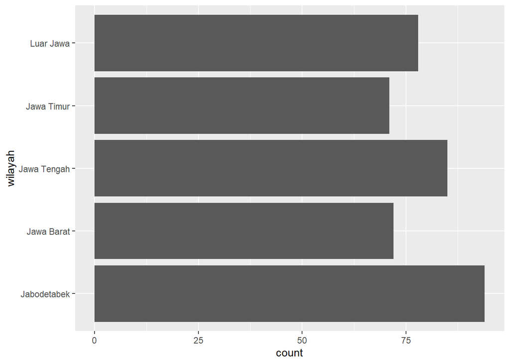

```r
ggplot(data_raw, aes(x = wilayah)) +
  geom_bar() +
  coord_flip()
```

Informasinya sama persis. Namun pada grafik, wilayah dengan peserta terbanyak dan tersedikit langsung terlihat tanpa perlu membandingkan angka satu per satu.

> **Prinsip pertama:** grafik bukan hiasan laporan, melainkan alat untuk mempercepat pemahaman.

## 3.2 Tiga tujuan visualisasi

Sebelum membuat grafik, tentukan dulu: grafik ini untuk siapa dan untuk apa? Jawabannya menentukan seberapa sederhana atau seberapa rapi grafik yang dibuat.

| Tujuan | Penjelasan | Penontonnya | Tingkat kerapian |
| --- | --- | --- | --- |
| **Eksplorasi** (*explore*) | Memahami data yang baru diterima: bagaimana distribusinya, adakah nilai aneh, adakah data hilang | Analis sendiri | Seadanya, default `ggplot2` sudah cukup |
| **Analisis** (*analyze*) | Menguji dugaan: apakah dua kelompok benar berbeda, apakah dua variabel bergerak bersama | Analis dan tim | Sedang, label perlu jelas |
| **Komunikasi** (*explain*) | Menyampaikan satu temuan kepada klien atau pimpinan | Orang lain | Tinggi: judul, label, anotasi lengkap |

### Perbedaan penting

Grafik eksplorasi boleh berantakan dan dibuang setelah dipakai.

Grafik komunikasi harus dapat dimengerti **tanpa kehadiran pembuatnya**. Semua konteks (judul, satuan, periode, sumber data) harus menempel pada grafik itu sendiri.

Pada ujian PAI, grafik yang diminta umumnya berada di antara keduanya: **tepat secara analisis, dan cukup jelas untuk dibaca penguji**.

## 3.3 Exploratory vs Explanatory

| Aspek | Exploratory | Explanatory |
| --- | --- | --- |
| Tujuan | Menemukan sesuatu yang belum diketahui | Menyampaikan temuan yang sudah dipastikan |
| Jumlah grafik | Banyak, dibuat cepat, sebagian dibuang | Sedikit, terpilih, dipoles |
| Pertanyaan pemandu | “Ada apa di data ini?” | “Apa satu hal yang harus diingat pembaca?” |
| Contoh pada dataset ini | Membuat histogram semua variabel numerik untuk melihat sebarannya | Satu boxplot usia per status klaim dengan judul berisi temuan |

## 3.4 Apa yang sebenarnya kita cari dalam sebuah grafik?

Grafik dibuat untuk menjawab pertanyaan. Enam pertanyaan berikut hampir selalu relevan.

| Pola | Pertanyaan | Grafik yang lazim |
| --- | --- | --- |
| **Distribution** | Bagaimana sebarannya? Di mana nilai menumpuk? | Histogram, density, boxplot |
| **Difference** | Adakah perbedaan antar kelompok? | Bar, boxplot, violin |
| **Association** | Adakah hubungan antar dua variabel? | Scatter plot |
| **Trend** | Bagaimana pergerakan sepanjang waktu? | Line chart, area chart |
| **Cluster** | Adakah pengelompokan alami? | Scatter plot + warna |
| **Anomaly** | Adakah nilai yang menyimpang? | Boxplot, scatter plot |

Pada konteks BPJS, contohnya:

- *Distribution* → bagaimana sebaran usia peserta?
- *Difference* → apakah waktu tunggu berbeda antar fasilitas?
- *Association* → apakah jumlah kunjungan berkaitan dengan biaya klaim?
- *Trend* → bagaimana jumlah kunjungan berubah tiap bulan?
- *Cluster* → adakah kelompok peserta dengan pola pemanfaatan yang mirip?
- *Anomaly* → adakah biaya klaim yang nilainya tidak wajar?

# 4. Prinsip Dasar Visualisasi

## 4.1 Anatomi sebuah grafik

Setiap grafik tersusun dari elemen yang sama. Mengenali namanya memudahkan saat harus memperbaikinya di `ggplot2`.

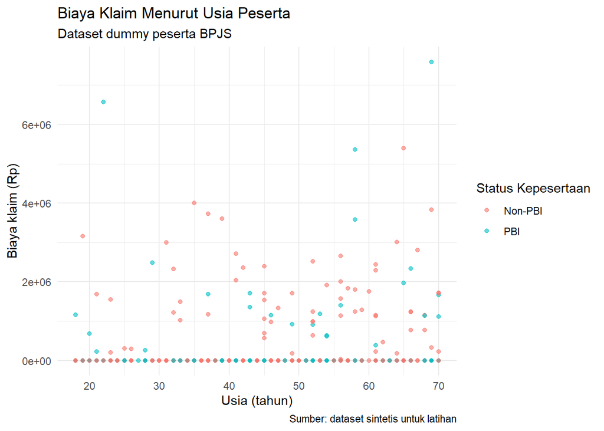

| Elemen | Fungsi | Yang dicek saat membaca | Fungsi `ggplot2` |
| --- | --- | --- | --- |
| Title | Menyatakan isi atau temuan | Apakah judul sesuai isi? | `labs(title=)` |
| Subtitle | Konteks: periode, subset, sumber | Data kapan? Populasi mana? | `labs(subtitle=)` |
| X-axis | Variabel pada sumbu horizontal | Apa variabel dan satuannya? | `labs(x=)`, `scale_x_*` |
| Y-axis | Variabel pada sumbu vertikal | Apakah dimulai dari nol? | `labs(y=)`, `scale_y_*` |
| Scale | Pemetaan nilai ke jarak visual | Linear atau log? Terpotong? | `scale_*_continuous()` |
| Legend | Menerjemahkan warna/bentuk | Apakah semua warna dijelaskan? | `labs(color=)`, `guides()` |
| Gridline | Bantuan membaca nilai | Terlalu ramai? | `theme(panel.grid)` |
| Annotation | Menyorot titik/area penting | Apakah menyorot hal relevan? | `annotate()`, `geom_text()` |

```r
ggplot(data_raw, aes(x = usia, y = biaya_klaim, color = status_kepesertaan)) +
  geom_point(alpha = 0.6) +
  labs(
    title = "Biaya Klaim Menurut Usia Peserta",
    subtitle = "Dataset dummy peserta BPJS",
    x = "Usia (tahun)",
    y = "Biaya klaim (Rp)",
    color = "Status Kepesertaan",
    caption = "Sumber: dataset sintetis untuk latihan"
  ) +
  theme_minimal()
```

Elemen bukan sekadar hiasan. Setiap elemen adalah keputusan yang memengaruhi kesimpulan pembaca.

## 4.2 Tiga prinsip: clarity, accuracy, readability

### Clarity — kejelasan

Satu grafik menyampaikan **satu pesan utama**. Hilangkan elemen yang tidak membantu pesan itu.

Uji cepat: dapatkah orang lain menyebutkan pesan grafik ini dalam 5 detik?

### Accuracy — ketepatan

Visual harus proporsional dengan angkanya.

- Bar chart wajib dimulai dari nol, karena pembaca membandingkan **panjang batang**.
- Jangan memotong sumbu untuk membesar-besarkan selisih.
- Jangan memakai luas area untuk mewakili nilai linear.

Uji cepat: apakah selisih visual sama dengan selisih angka?

### Readability — keterbacaan

Teks cukup besar, label tidak bertumpuk, kategori diurutkan logis, dan warna tetap terbaca saat dicetak hitam-putih.

Uji cepat: apakah grafik masih terbaca ketika ditampilkan lewat proyektor?

## 4.3 Kesalahan umum yang menyesatkan pembaca

Grafik yang “jalan” belum tentu jujur. Empat kesalahan berikut paling sering muncul.

### 1. Sumbu Y dipotong

Memulai sumbu Y dari nilai selain nol membuat selisih kecil terlihat sangat besar.

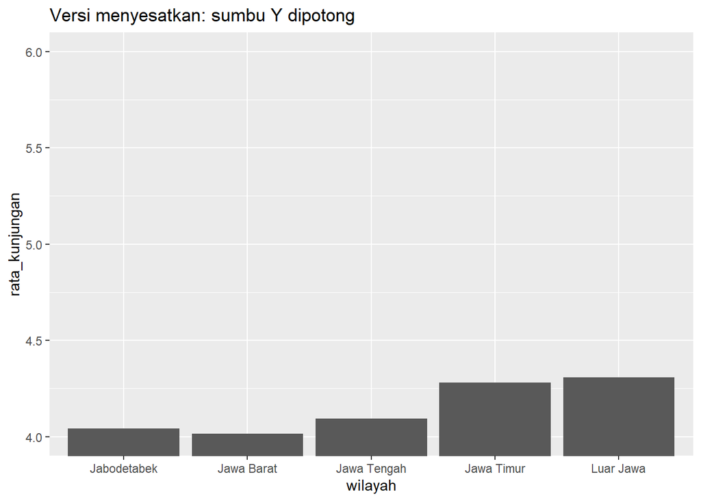

```r
rata_kunjungan_wilayah <- data_raw %>%
  group_by(wilayah) %>%
  summarise(rata_kunjungan = mean(kunjungan_12_bulan))

# MENYESATKAN: sumbu dipotong sehingga selisih kecil terlihat dramatis
ggplot(rata_kunjungan_wilayah, aes(x = wilayah, y = rata_kunjungan)) +
  geom_col() +
  coord_cartesian(ylim = c(4, 6)) +
  labs(title = "Versi menyesatkan: sumbu Y dipotong")
```

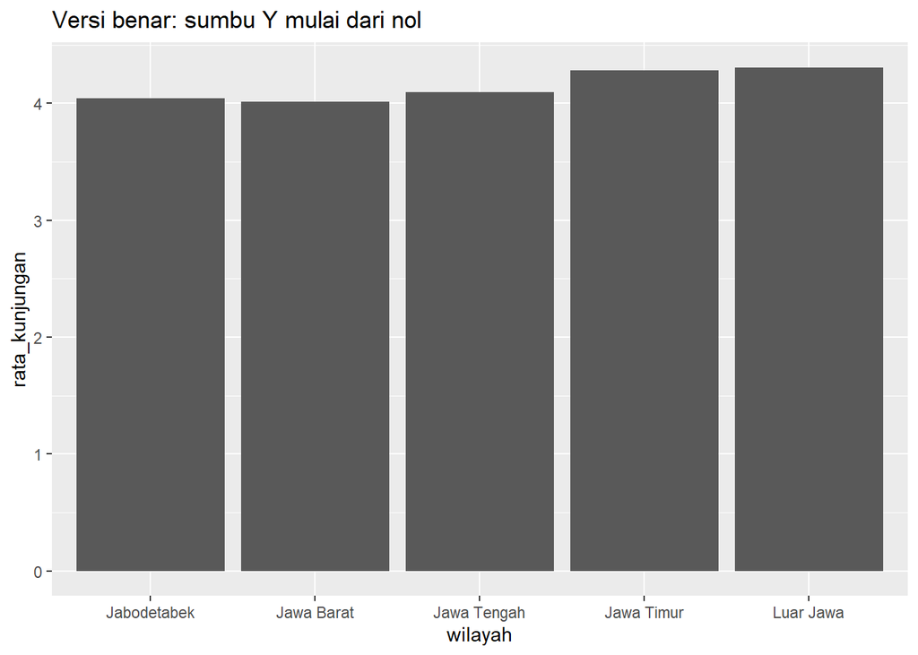

```r
# BENAR: sumbu dimulai dari nol
ggplot(rata_kunjungan_wilayah, aes(x = wilayah, y = rata_kunjungan)) +
  geom_col() +
  labs(title = "Versi benar: sumbu Y mulai dari nol")
```

Perhatikan bahwa kesimpulan yang muncul dari kedua grafik dapat sangat berbeda padahal datanya identik.

### 2. Terlalu banyak warna

Grafik dengan banyak warna memaksa mata bolak-balik ke legend. Batasi 2–5 warna. Sorot kelompok penting dengan satu warna, sisanya abu-abu.

### 3. Pie chart untuk banyak kategori

Mata sulit membandingkan sudut. Pie dengan banyak irisan hampir mustahil diurutkan secara akurat. Gunakan bar chart terurut.

### 4. Kategori diurutkan menurut abjad

Urutan abjad tidak bermakna. Gunakan `reorder()`, kecuali kategorinya memang berurutan alami (misalnya bulan).

# 5. Memahami Variabel

Dataset ini mensimulasikan data peserta BPJS dan pemanfaatan layanan.

| Variabel | Tipe | Keterangan |
| --- | --- | --- |
| `id_peserta` | Kategorikal/ID | ID peserta |
| `usia` | Numerik | Usia peserta |
| `jenis_kelamin` | Kategorikal | Laki-laki/Perempuan |
| `wilayah` | Kategorikal | Wilayah tempat peserta |
| `status_kepesertaan` | Kategorikal | PBI/Non-PBI |
| `status_pekerjaan` | Kategorikal | Status pekerjaan |
| `fasilitas_utama` | Kategorikal | Fasilitas layanan utama |
| `penyakit_kronis` | Kategorikal | Ada/tidak ada |
| `iuran_bulanan` | Numerik | Iuran bulanan sintetis |
| `kunjungan_12_bulan` | Numerik | Jumlah kunjungan dalam 12 bulan |
| `status_klaim` | Kategorikal | Pernah/belum klaim |
| `biaya_klaim` | Numerik | Biaya klaim sintetis |
| `waktu_tunggu_hari` | Numerik | Waktu tunggu |
| `kepuasan` | Numerik | Skor kepuasan 1–5 |
| `bulan_kunjungan` | Tanggal | Bulan kunjungan sintetis |
| `tahun_bulan` | Kategorikal/temporal | Tahun-bulan untuk ringkasan |
| `tanggal_kunjungan` | Tanggal | Tanggal kunjungan sintetis |
| `jenis_layanan` | Kategorikal | Jenis layanan sintetis |

## 5.1 Mengapa tipe variabel penting?

Karena **jenis variabel membantu menentukan grafik**.

Contoh:

- kategorikal → bar chart;
- numerik → histogram/boxplot;
- kategorikal × numerik → boxplot;
- numerik × numerik → scatter plot;
- kategorikal × kategorikal → bar chart dengan `fill`.

Ini adalah salah satu pola terpenting dalam Data Visualization.

# 6. Memilih Grafik yang Tepat

Bagian sebelumnya menjelaskan **tipe variabel**. Bagian ini menjelaskan cara mengubah tipe variabel itu menjadi keputusan grafik.

## 6.1 Langkah 1 — Kenali kombinasi variabelnya

| Kombinasi variabel | Pertanyaan yang dijawab | Grafik yang sesuai | `geom` |
| --- | --- | --- | --- |
| 1 kategorik | Kategori mana paling sering muncul? | Bar chart | `geom_bar()` |
| 1 numerik | Bagaimana bentuk sebarannya? | Histogram, density, boxplot | `geom_histogram()` |
| 1 kat × 1 num | Apakah nilainya berbeda antar kelompok? | Boxplot, violin, bar ringkasan | `geom_boxplot()` |
| 1 kat × 1 kat | Bagaimana komposisi antar kelompok? | Grouped / stacked / 100% bar | `geom_bar(position=)` |
| 1 num × 1 num | Apakah dua variabel berhubungan? | Scatter plot | `geom_point()` |
| Waktu × numerik | Bagaimana pergerakan sepanjang waktu? | Line chart, area chart | `geom_line()` |
| 2 num × 1 kat | Apakah pola hubungan beda antar kelompok? | Scatter + `color` atau facet | `geom_point(aes(color=))` |

## 6.2 Langkah 2 — Tentukan tujuan analisisnya

Kombinasi variabel menyempitkan pilihan; **tujuan analisis** menentukan pilihan akhirnya.

| Tujuan | Maksudnya | Grafik |
| --- | --- | --- |
| Comparison | Membandingkan nilai antar kategori | Bar terurut, boxplot, dot plot |
| Distribution | Melihat bentuk sebaran satu variabel | Histogram, density, boxplot |
| Relationship | Melihat apakah dua numerik bergerak bersama | Scatter plot |
| Composition | Melihat porsi penyusun keseluruhan | Stacked bar, 100% stacked bar, pie |
| Trend | Melihat arah perubahan sepanjang waktu | Line chart, area chart |
| Anomaly | Menemukan nilai ekstrem | Boxplot, scatter plot |

## 6.3 Langkah 3 — Alur keputusan dalam empat pertanyaan

1. **Pertanyaan apa?** Rumuskan dalam satu kalimat.
2. **Variabel apa?** Identifikasi variabel dan tipenya.
3. **Tujuan apa?** Comparison, distribution, relationship, composition, trend, atau anomaly.
4. **Grafik mana?** Pilih dari tabel di atas.

### Contoh penerapan pada dataset BPJS

| Langkah | Isi |
| --- | --- |
| Pertanyaan | “Apakah waktu tunggu berbeda antar fasilitas utama?” |
| Variabel | `fasilitas_utama` (kategorik) × `waktu_tunggu_hari` (numerik) |
| Tujuan | Comparison sekaligus distribution |
| Grafik | Boxplot waktu tunggu per fasilitas |

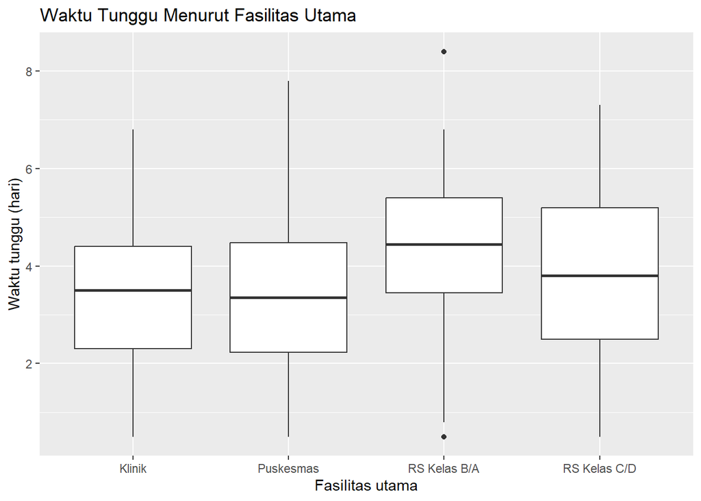

```r
ggplot(data_raw, aes(x = fasilitas_utama, y = waktu_tunggu_hari)) +
  geom_boxplot() +
  labs(
    title = "Waktu Tunggu Menurut Fasilitas Utama",
    x = "Fasilitas utama",
    y = "Waktu tunggu (hari)"
  )
```

> **Kesalahan berpikir yang sering terjadi:** memilih grafik karena “pie chart terlihat menarik”. Kalau pertanyaannya belum jelas, grafik apa pun akan terasa kurang pas dan kita akan terus menggantinya tanpa tahu apa yang dicari.

# 7. Konsep Dasar `ggplot2`

Struktur paling dasar:

```r
ggplot(data = data_raw, aes(x = usia)) +
  geom_histogram()
```

Ada tiga bagian utama:

### `ggplot()`

Menentukan dataset yang akan digunakan.

### `aes()`

Menentukan **aesthetic mapping**, yaitu variabel data akan digunakan untuk apa.

Contoh:

```r
aes(x = usia)
```

artinya `usia` ditempatkan pada sumbu X.

### `geom_*()`

Menentukan bentuk grafik.

Contoh:

```r
geom_histogram()
```

artinya membuat histogram.

> Pola yang perlu diingat:

> **data → aes() → geom**

## 7.1 Grammar of Graphics: grafik sebagai tumpukan lapisan

Nama “gg” pada `ggplot2` berasal dari **Grammar of Graphics**. Idenya: grafik tidak dipilih sebagai “jenis chart siap pakai”, melainkan **disusun dari lapisan komponen** — seperti menyusun kalimat mengikuti tata bahasa.

Urutan lapisannya, dari yang wajib sampai yang opsional:

| Lapisan | Fungsi | Status |
| --- | --- | --- |
| **Data** | Dataset yang digambar | Wajib |
| **Aesthetics** (`aes`) | Pemetaan variabel ke properti visual | Wajib |
| **Geometries** (`geom_*`) | Bentuk visual: titik, garis, batang | Wajib |
| **Statistics** (`stat_*`) | Transformasi statistik sebelum digambar | Opsional |
| **Facets** | Membagi grafik menjadi panel kecil | Opsional |
| **Coordinates** (`coord_*`) | Sistem koordinat | Opsional |
| **Theme** | Tampilan non-data: warna latar, font, grid | Opsional |

Semua lapisan disambung dengan tanda `+`.

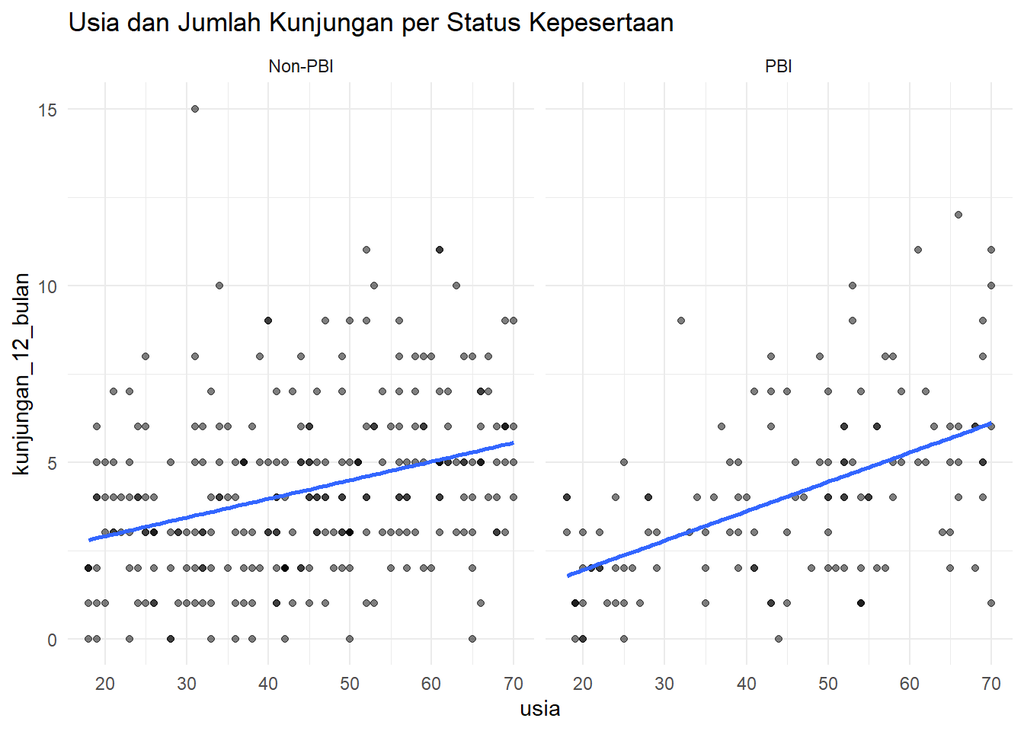

```r
ggplot(data_raw, aes(x = usia, y = kunjungan_12_bulan)) +   # data + aes
  geom_point(alpha = 0.5) +                                  # geom
  geom_smooth(method = "lm", se = FALSE) +                   # stat
  facet_wrap(~ status_kepesertaan) +                         # facet
  labs(title = "Usia dan Jumlah Kunjungan per Status Kepesertaan") +
  theme_minimal()                                            # theme
```

Konsekuensi penting: **sekali memahami polanya, semua jenis grafik mengikuti struktur kode yang sama.** Yang berubah hanya `geom` dan variabel di dalam `aes()`.

## 7.2 Komponen yang perlu dikenali

### `ggplot()` — kanvas

Membuat “kanvas kosong”. Dijalankan sendirian, hasilnya hanya area abu-abu tanpa isi.

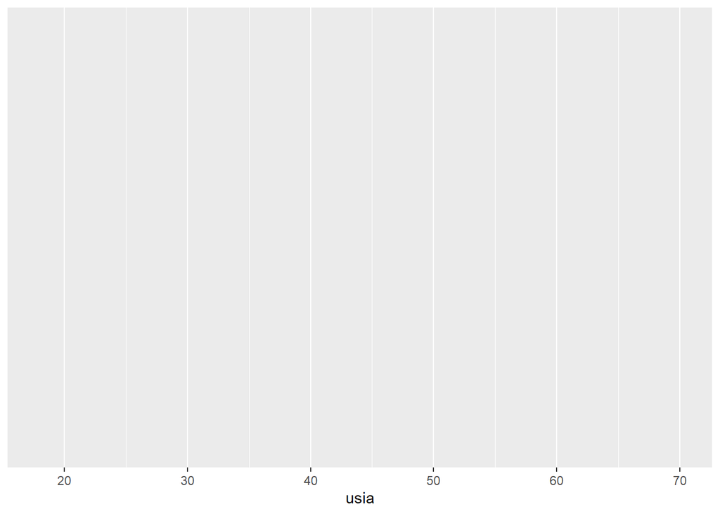

```r
ggplot(data_raw, aes(x = usia))
```

Belum ada `geom`, sehingga belum ada yang digambar.

### `stat_*()` — transformasi statistik

Beberapa `geom` diam-diam melakukan perhitungan:

- `geom_bar()` menghitung **frekuensi** tiap kategori;
- `geom_histogram()` menghitung frekuensi tiap **bin**;
- `geom_boxplot()` menghitung median dan kuartil;
- `geom_smooth()` menghitung garis tren.

Karena itu `geom_bar()` tidak memerlukan `y` — nilai `y` dihitung sendiri oleh `ggplot2`.

### `scale_*()` — skala

Mengatur bagaimana nilai data diterjemahkan ke visual: rentang sumbu, palet warna, dan format label.

```
## Warning in prettyNum(.Internal(format(x, trim, digits, nsmall, width, 3L, :
## 'big.mark' and 'decimal.mark' are both '.', which could be confusing
```

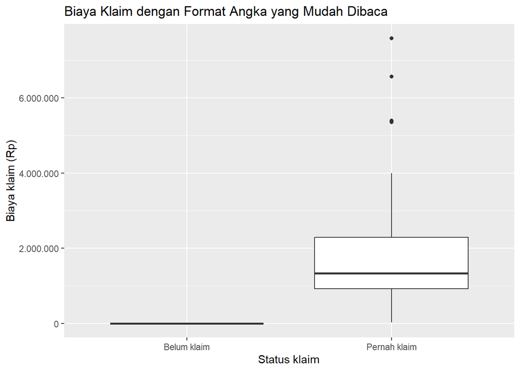

```r
ggplot(data_raw, aes(x = status_klaim, y = biaya_klaim)) +
  geom_boxplot() +
  scale_y_continuous(labels = function(x) format(x, big.mark = ".", scientific = FALSE)) +
  labs(title = "Biaya Klaim dengan Format Angka yang Mudah Dibaca",
       x = "Status klaim", y = "Biaya klaim (Rp)")
```

### `coord_*()` — sistem koordinat

Default-nya kartesian. `coord_flip()` membalik sumbu, `coord_polar()` mengubah bar menjadi pie.

## 7.3 Mapping vs Setting: di dalam `aes()` atau di luar?

Ini sumber kebingungan paling umum bagi pemula, dan sering muncul sebagai kesalahan di ujian.

### Mapping — di **dalam** `aes()`

Warna ditentukan oleh **nilai kolom data**. `ggplot2` otomatis membuat legend.

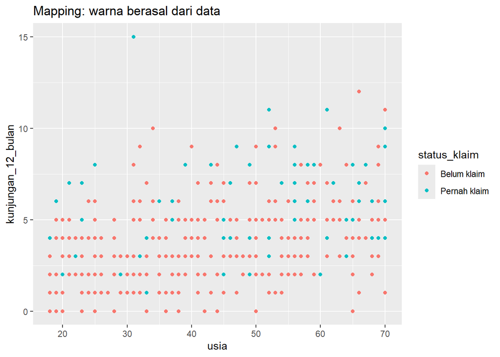

```r
ggplot(data_raw, aes(x = usia, y = kunjungan_12_bulan)) +
  geom_point(aes(color = status_klaim)) +
  labs(title = "Mapping: warna berasal dari data")
```

### Setting — di **luar** `aes()`

Warna ditetapkan manual dan berlaku sama untuk semua titik. Tidak ada legend.

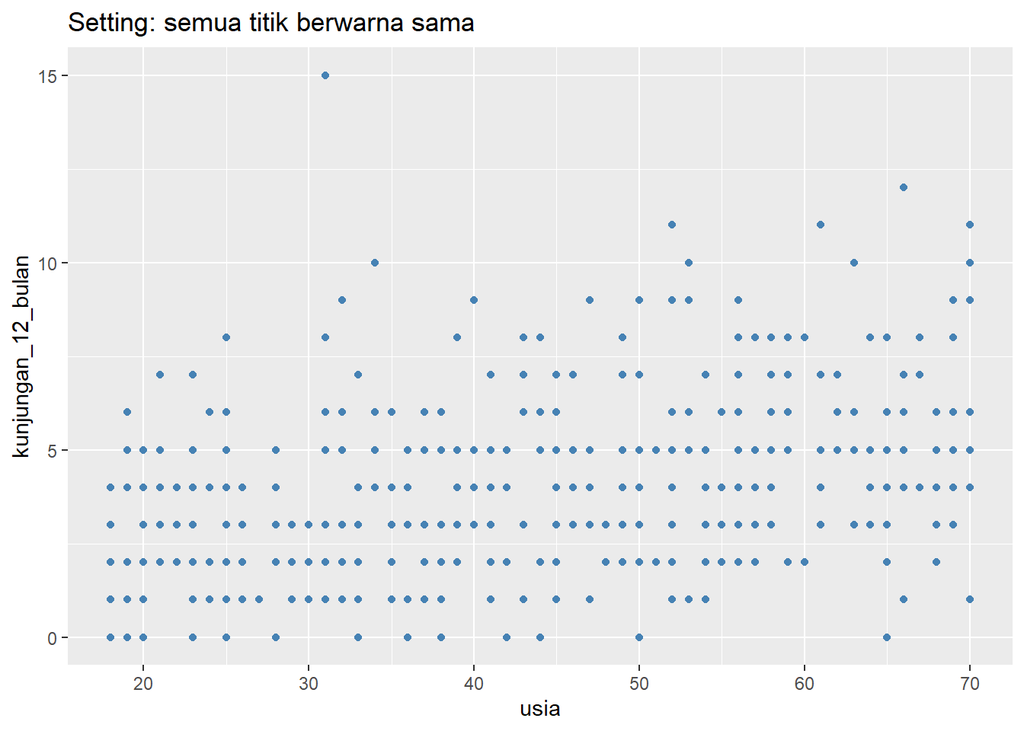

```r
ggplot(data_raw, aes(x = usia, y = kunjungan_12_bulan)) +
  geom_point(color = "steelblue") +
  labs(title = "Setting: semua titik berwarna sama")
```

### Kesalahan klasik

```r
# SALAH
geom_point(aes(color = "red"))
```

Kode di atas membuat semua titik berwarna merah-oranye **dan** memunculkan legend bertuliskan `"red"`. Penyebabnya: `ggplot2` menganggap teks `"red"` sebagai data kategori baru, bukan sebagai nama warna.

Perbaikannya: pindahkan `color` ke luar `aes()`.

```r
# BENAR
geom_point(color = "red")
```

### Cara mengingat

Tanyakan: **apakah nilainya berasal dari kolom data?**

- Ya → masuk ke dalam `aes()`.
- Tidak, saya tentukan sendiri dan sama untuk semua baris → di luar `aes()`.

# 8. Data Preparation untuk Visualisasi

`ggplot2` tidak mengolah data. **Bentuk data yang masuk menentukan bentuk grafik yang keluar.** Karena itu banyak soal visualisasi sebenarnya adalah soal penyiapan data.

## 8.1 Syarat data yang siap divisualisasikan: tidy data

- satu **baris** = satu observasi (di sini: satu peserta);
- satu **kolom** = satu variabel;
- satu **sel** = satu nilai.

Dataset kita sudah memenuhi syarat ini, sehingga dapat langsung dipakai.

## 8.2 Tiga masalah yang paling sering muncul

| Masalah | Contoh pada dataset BPJS | Solusinya |
| --- | --- | --- |
| Data belum diringkas | Ingin menampilkan rata-rata biaya klaim per wilayah, tetapi data masih per peserta | `group_by()` + `summarise()` |
| Data terlalu luas | Ingin fokus pada peserta yang pernah klaim saja | `filter()` |
| Kolom belum tersedia | Ingin menggambar kelompok usia, padahal kolomnya baru usia mentah | `mutate()` |

## 8.3 Enam fungsi `dplyr` yang paling sering dipakai

### `filter()` — menyaring baris

```r
data_klaim <- data_raw %>%
  filter(status_klaim == "Pernah klaim")

nrow(data_klaim)
```

```
## [1] 89
```

Berguna karena `biaya_klaim` bernilai 0 untuk peserta yang belum klaim. Jika tidak disaring, rata-rata biaya klaim akan tertarik ke bawah oleh nilai nol tersebut.

### `select()` — memilih kolom

```r
data_raw %>%
  select(id_peserta, usia, wilayah, status_klaim, biaya_klaim) %>%
  head()
```

```
##   id_peserta usia     wilayah status_klaim biaya_klaim
## 1   BPJS0001   56  Jawa Timur Pernah klaim     1142000
## 2   BPJS0002   69  Jawa Barat Pernah klaim      322000
## 3   BPJS0003   46  Jawa Barat  Belum klaim           0
## 4   BPJS0004   32 Jawa Tengah Pernah klaim     2322000
## 5   BPJS0005   60  Jawa Barat Pernah klaim     1756000
## 6   BPJS0006   25  Jawa Barat  Belum klaim           0
```

### `mutate()` — membuat kolom baru

```r
data_kelompok <- data_raw %>%
  mutate(
    kelompok_usia = case_when(
      usia < 25 ~ "Di bawah 25",
      usia < 45 ~ "25-44",
      usia < 60 ~ "45-59",
      TRUE      ~ "60 ke atas"
    )
  )

data_kelompok %>%
  count(kelompok_usia)
```

```
##   kelompok_usia   n
## 1         25-44 138
## 2         45-59 126
## 3    60 ke atas  81
## 4   Di bawah 25  55
```

`case_when()` membuat kategori baru berdasarkan kondisi, dibaca dari atas ke bawah. `TRUE ~` berarti “sisanya”.

### `group_by()` dan `summarise()` — meringkas per kelompok

```r
ringkasan_wilayah <- data_raw %>%
  filter(status_klaim == "Pernah klaim") %>%
  group_by(wilayah) %>%
  summarise(
    jumlah_peserta = n(),
    rata_biaya     = mean(biaya_klaim),
    median_biaya   = median(biaya_klaim)
  )

ringkasan_wilayah
```

```
## # A tibble: 5 × 4
##   wilayah     jumlah_peserta rata_biaya median_biaya
##   <chr>                <int>      <dbl>        <dbl>
## 1 Jabodetabek             15   2035600       1838000
## 2 Jawa Barat              18   1376833.      1339500
## 3 Jawa Tengah             21   1882571.      1232000
## 4 Jawa Timur              12   1410250       1422500
## 5 Luar Jawa               23   1734913.      1237000
```

### `arrange()` — mengurutkan baris

```r
ringkasan_wilayah %>%
  arrange(desc(rata_biaya))
```

```
## # A tibble: 5 × 4
##   wilayah     jumlah_peserta rata_biaya median_biaya
##   <chr>                <int>      <dbl>        <dbl>
## 1 Jabodetabek             15   2035600       1838000
## 2 Jawa Tengah             21   1882571.      1232000
## 3 Luar Jawa               23   1734913.      1237000
## 4 Jawa Timur              12   1410250       1422500
## 5 Jawa Barat              18   1376833.      1339500
```

## 8.4 Merangkai `dplyr` dan `ggplot2` dalam satu alur

Perhatikan aturan operator:

- antar langkah `dplyr` memakai **`%>%`**;
- antar lapisan `ggplot2` memakai **`+`**.

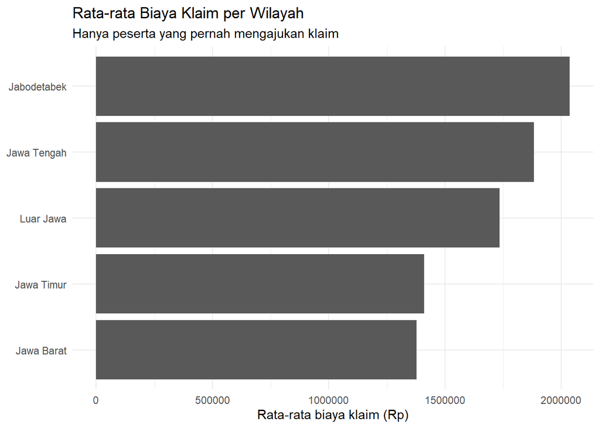

```r
data_raw %>%
  filter(status_klaim == "Pernah klaim") %>%
  group_by(wilayah) %>%
  summarise(rata_biaya = mean(biaya_klaim)) %>%
  ggplot(aes(x = reorder(wilayah, rata_biaya), y = rata_biaya)) +
  geom_col() +
  coord_flip() +
  labs(
    title = "Rata-rata Biaya Klaim per Wilayah",
    subtitle = "Hanya peserta yang pernah mengajukan klaim",
    x = NULL,
    y = "Rata-rata biaya klaim (Rp)"
  ) +
  theme_minimal()
```

Urutan langkahnya:

1. `filter()` membatasi pada peserta yang pernah klaim;
2. `group_by()` menandai perhitungan dilakukan per wilayah;
3. `summarise()` meringkas menjadi satu baris per wilayah;
4. `ggplot()` menerima data ringkasan tersebut;
5. `geom_col()` menggambar batang setinggi nilai rata-rata;
6. `coord_flip()` membalik agar label wilayah mudah dibaca.

## 8.5 `geom_bar()` vs `geom_col()`

Ini perbedaan yang paling sering menjadi sumber kesalahan.

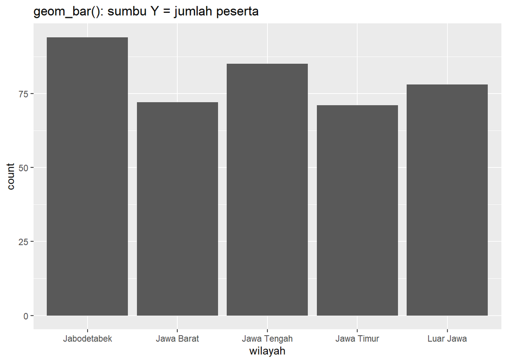

```r
# geom_bar(): menghitung JUMLAH PESERTA per wilayah
ggplot(data_raw, aes(x = wilayah)) +
  geom_bar() +
  labs(title = "geom_bar(): sumbu Y = jumlah peserta")
```

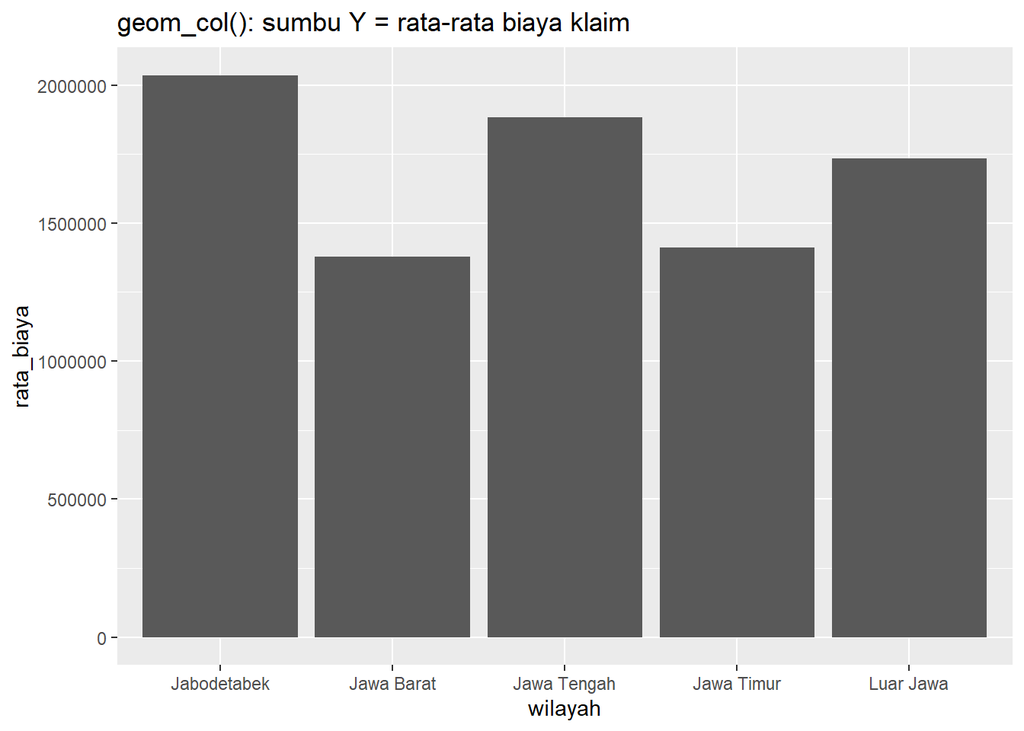

```r
# geom_col(): memakai NILAI dari data ringkasan
ggplot(ringkasan_wilayah, aes(x = wilayah, y = rata_biaya)) +
  geom_col() +
  labs(title = "geom_col(): sumbu Y = rata-rata biaya klaim")
```

Perhatikan bahwa wilayah dengan **peserta terbanyak** belum tentu wilayah dengan **rata-rata biaya tertinggi**. Pemilihan agregasi menentukan kesimpulan.

# 9. Univariate Visualization: Variabel Kategorikal

Univariate berarti kita mengeksplorasi **satu variabel**.

## 9.1 Bar Chart

Pertanyaan:

> Bagaimana komposisi peserta berdasarkan status kepesertaan?

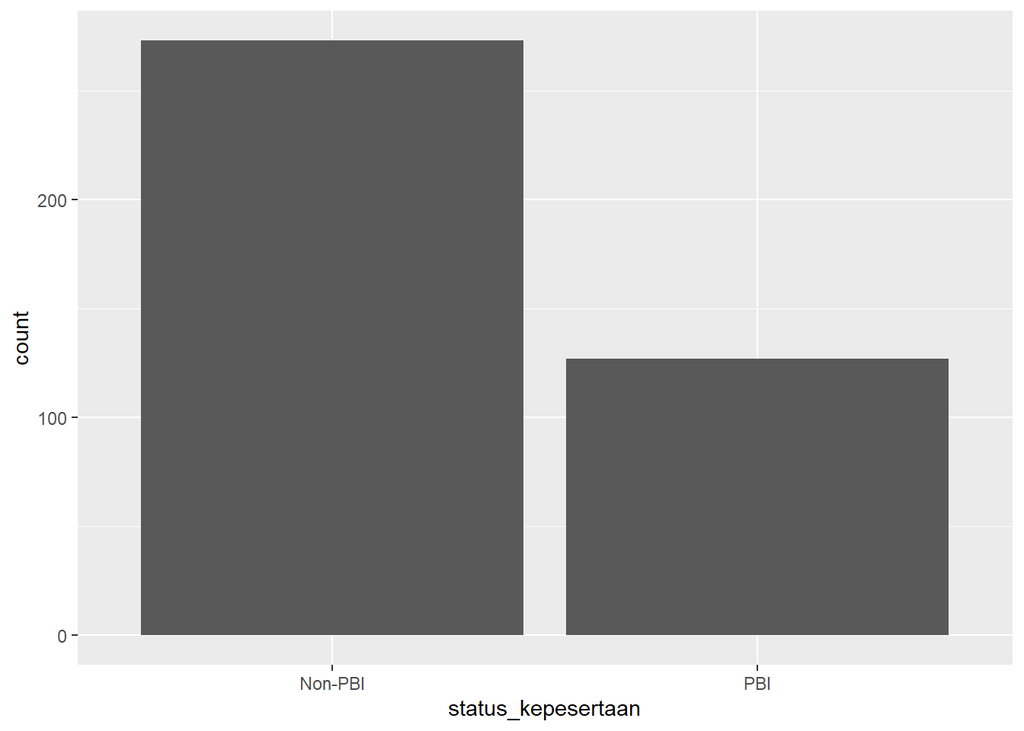

```r
ggplot(data_raw, aes(x = status_kepesertaan)) +
  geom_bar()
```

`geom_bar()` menghitung jumlah observasi secara otomatis.

### Parameter penting

`x = status_kepesertaan`

→ variabel yang akan dibandingkan.

### Interpretasi

Tuliskan pola utama saja.

Contoh format:

> Berdasarkan grafik, peserta Non-PBI terlihat lebih banyak dibandingkan peserta PBI.

Jangan hanya menulis:

> “Grafiknya menunjukkan status kepesertaan.”

Interpretasi harus menyebutkan **temuan**.

## 9.2 Bar Chart Berdasarkan Kelompok

Pertanyaan:

> Bagaimana status klaim berdasarkan wilayah?

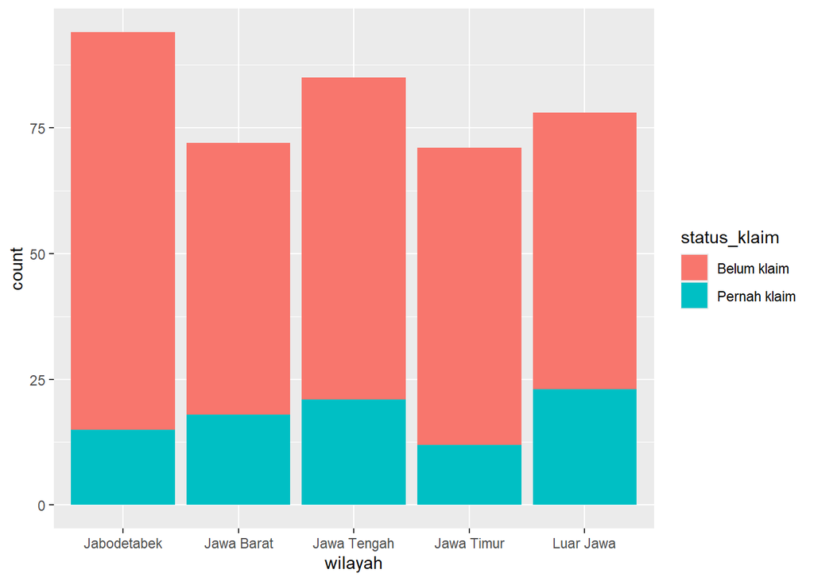

```r
ggplot(data_raw, aes(x = wilayah, fill = status_klaim)) +
  geom_bar()
```

Di sini terdapat dua variabel:

- `wilayah` → sumbu X;
- `status_klaim` → warna/pengelompokan.

`fill` digunakan untuk membedakan kelompok di dalam bar.

Karena wilayah lebih dari beberapa kategori, grafik dapat dibuat horizontal:

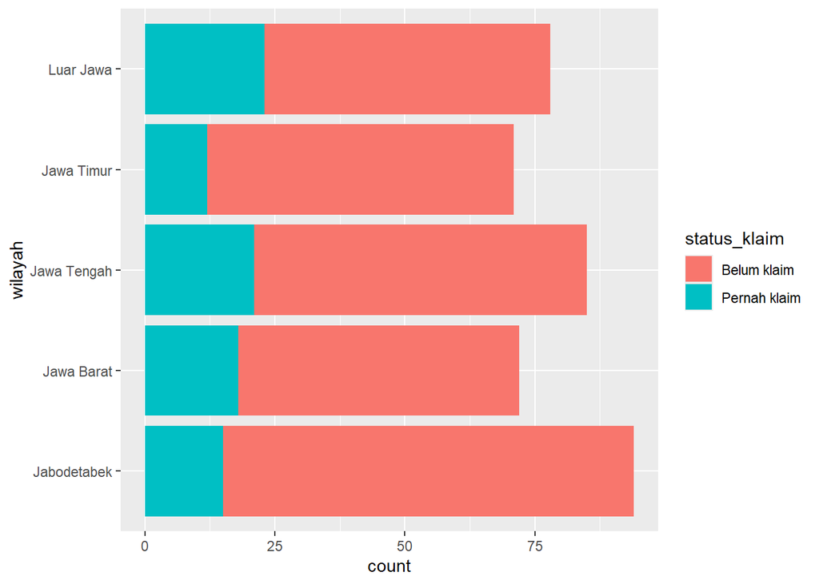

```r
ggplot(data_raw, aes(x = wilayah, fill = status_klaim)) +
  geom_bar() +
  coord_flip()
```

`coord_flip()` menukar orientasi sumbu X dan Y sehingga label lebih mudah dibaca.

## 9.3 Menyajikan Proporsi dan Persentase

Jumlah absolut berguna, tetapi proporsi lebih mudah dibandingkan ketika jumlah anggota tiap kelompok berbeda.

```r
proporsi_fasilitas <- data_raw %>%
  count(fasilitas_utama) %>%
  mutate(persentase = n / sum(n) * 100)

proporsi_fasilitas
```

```
##   fasilitas_utama   n persentase
## 1          Klinik  85      21.25
## 2       Puskesmas 142      35.50
## 3    RS Kelas B/A  52      13.00
## 4    RS Kelas C/D 121      30.25
```

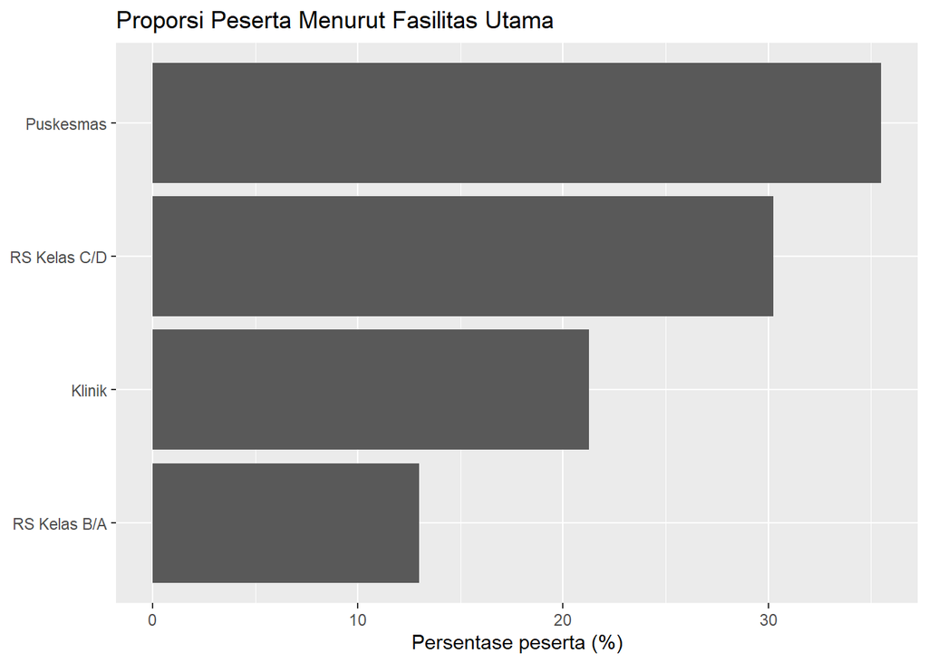

```r
ggplot(proporsi_fasilitas, aes(x = reorder(fasilitas_utama, persentase), y = persentase)) +
  geom_col() +
  coord_flip() +
  labs(
    title = "Proporsi Peserta Menurut Fasilitas Utama",
    x = NULL,
    y = "Persentase peserta (%)"
  )
```

### Fungsi yang dipakai

`count()`

→ menghitung jumlah baris per kategori, pintasan dari `group_by()` + `summarise(n = n())`.

`sum(n)`

→ total seluruh baris, dipakai sebagai penyebut.

## 9.4 Mengurutkan Kategori

Secara default `ggplot2` mengurutkan kategori menurut **abjad**, urutan yang hampir tidak pernah bermakna.

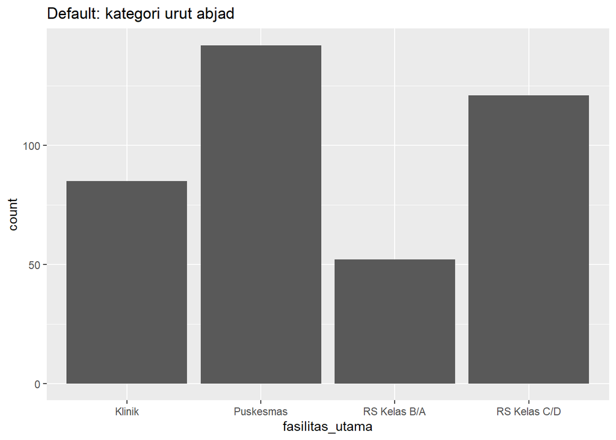

```r
# Default: urut abjad
ggplot(data_raw, aes(x = fasilitas_utama)) +
  geom_bar() +
  labs(title = "Default: kategori urut abjad")
```

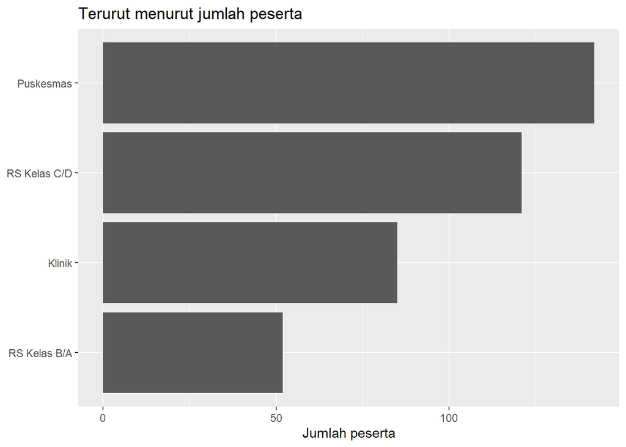

```r
# Terurut menurut jumlah peserta
data_raw %>%
  count(fasilitas_utama) %>%
  ggplot(aes(x = reorder(fasilitas_utama, n), y = n)) +
  geom_col() +
  coord_flip() +
  labs(title = "Terurut menurut jumlah peserta", x = NULL, y = "Jumlah peserta")
```

Gunakan `reorder(kategori, nilai)` untuk urut menaik, dan `reorder(kategori, -nilai)` untuk urut menurun.

### Yang dibaca dari bar chart

- kategori mana yang paling sering muncul (dominan);
- kategori mana yang jarang — apakah layak digabung menjadi “Lainnya”;
- seberapa timpang sebarannya: merata atau terpusat pada satu kategori;
- adakah kategori tak terduga: salah ketik, nilai kosong, atau label ganda.

# 10. Univariate Visualization: Variabel Numerik

## 10.1 Histogram

Pertanyaan:

> Bagaimana distribusi usia peserta?

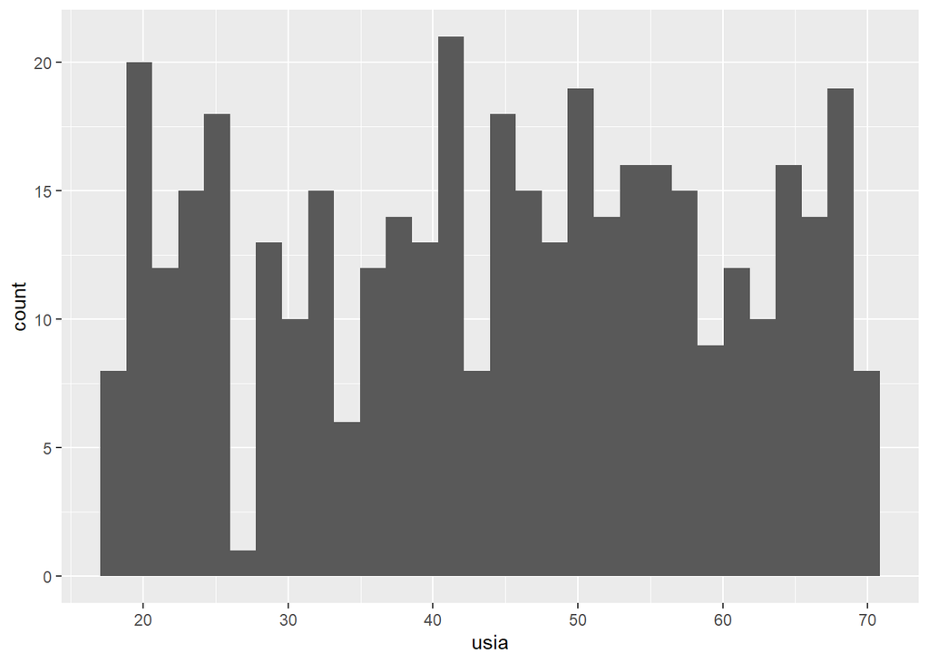

```r
ggplot(data_raw, aes(x = usia)) +
  geom_histogram()
```

Histogram digunakan untuk melihat **distribusi variabel numerik**.

Hal yang dapat diperhatikan:

- pusat distribusi;
- penyebaran;
- kemencengan/skewness;
- nilai yang sangat tinggi/rendah;
- pola distribusi.

## 10.2 Mengatur `bins`

Jumlah kelompok pada histogram dapat diatur menggunakan `bins`.

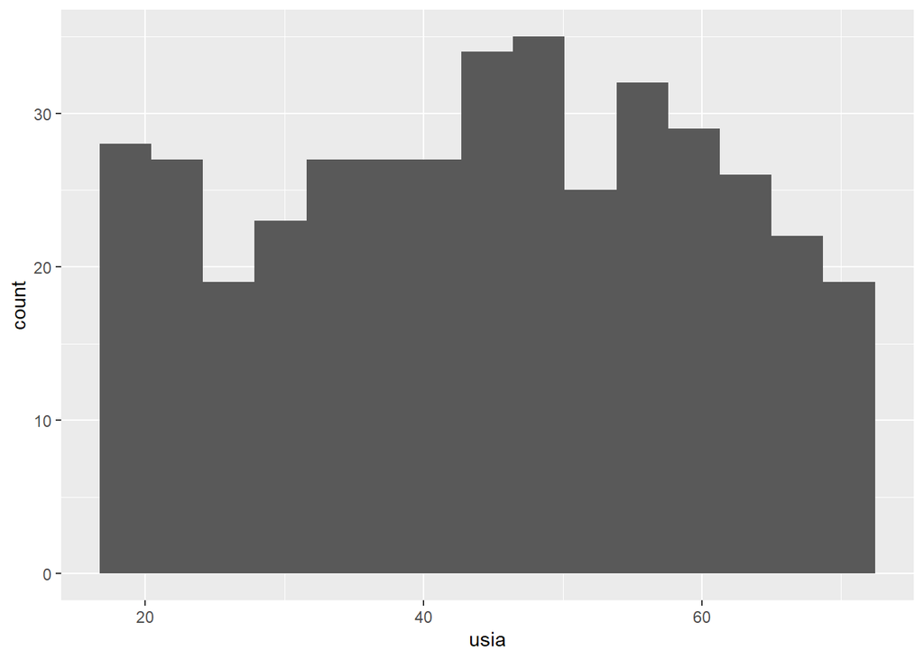

```r
ggplot(data_raw, aes(x = usia)) +
  geom_histogram(bins = 15)
```

`bins = 15`

→ data dibagi menjadi sekitar 15 kelompok interval.

Jangan menghafalkan angka tertentu. Pilih jumlah bins yang membuat pola distribusi cukup jelas.

## 10.3 Boxplot

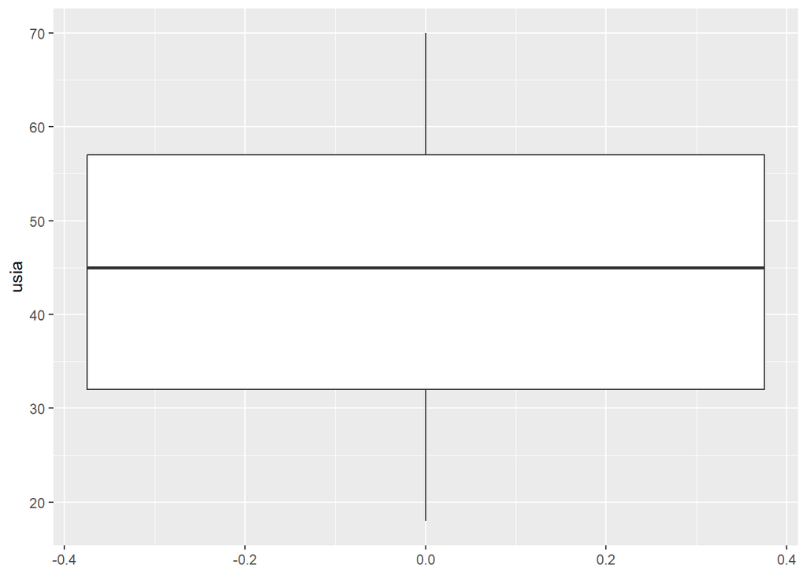

```r
ggplot(data_raw, aes(y = usia)) +
  geom_boxplot()
```

Boxplot membantu melihat:

- median;
- spread;
- kuartil;
- kemungkinan outlier.

## 10.4 Empat Hal yang Dibaca dari Sebuah Distribusi

Ketika melihat histogram, density plot, atau boxplot, jawab empat hal berikut.

### 1. Center — pusat data

Di sekitar nilai berapa data menumpuk?

```r
data_raw %>%
  summarise(
    rata_usia   = mean(usia),
    median_usia = median(usia)
  )
```

```
##   rata_usia median_usia
## 1     44.53          45
```

### 2. Spread — penyebaran

Seberapa lebar jarak antar nilai? Sebaran sempit berarti peserta relatif seragam.

```r
data_raw %>%
  summarise(
    minimum = min(usia),
    q1      = quantile(usia, 0.25),
    q3      = quantile(usia, 0.75),
    maksimum = max(usia),
    simpangan_baku = sd(usia)
  )
```

```
##   minimum q1 q3 maksimum simpangan_baku
## 1      18 32 57       70       15.32355
```

### 3. Shape — bentuk dan skewness

Simetris, miring ke kanan (ekor panjang di nilai besar), miring ke kiri, atau punya dua puncak (bimodal).

### 4. Outlier — pencilan

Nilai yang jauh terpisah dari kelompok utama. Periksa dulu penyebabnya: salah input, satuan berbeda, atau memang kasus nyata yang penting.

## 10.5 Mengapa Median Sering Lebih Aman daripada Rata-rata

Perhatikan variabel `biaya_klaim` pada peserta yang pernah klaim.

```r
data_raw %>%
  filter(status_klaim == "Pernah klaim") %>%
  summarise(
    rata_biaya   = mean(biaya_klaim),
    median_biaya = median(biaya_klaim)
  )
```

```
##   rata_biaya median_biaya
## 1    1704236      1335000
```

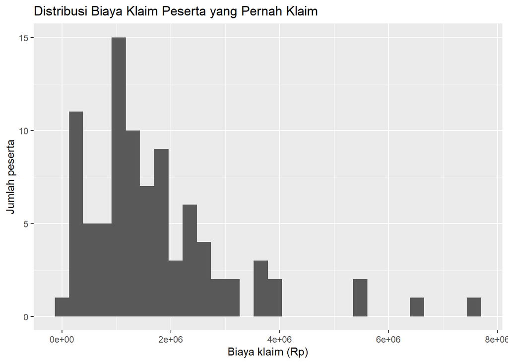

```r
data_raw %>%
  filter(status_klaim == "Pernah klaim") %>%
  ggplot(aes(x = biaya_klaim)) +
  geom_histogram(bins = 30) +
  labs(
    title = "Distribusi Biaya Klaim Peserta yang Pernah Klaim",
    x = "Biaya klaim (Rp)",
    y = "Jumlah peserta"
  )
```

Pada distribusi yang miring ke kanan, beberapa nilai sangat besar menarik **rata-rata** ke atas, sehingga rata-rata menjadi lebih tinggi daripada nilai yang dialami sebagian besar peserta. **Median** tetap berada di tengah barisan data dan tidak terpengaruh besarnya nilai ekstrem.

> Untuk distribusi miring, laporkan **median** dan sebutkan rentangnya — bukan sekadar rata-rata.

## 10.6 Pengaruh Pilihan `binwidth`

Binwidth menentukan cerita yang terlihat.

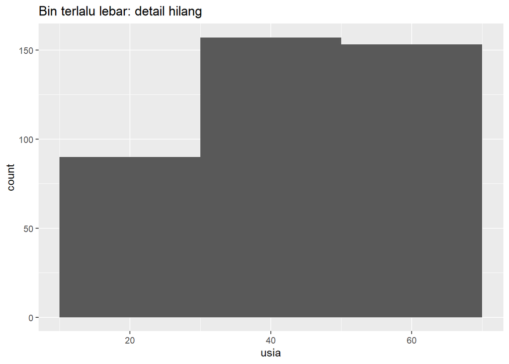

```r
ggplot(data_raw, aes(x = usia)) +
  geom_histogram(binwidth = 20) +
  labs(title = "Bin terlalu lebar: detail hilang")
```

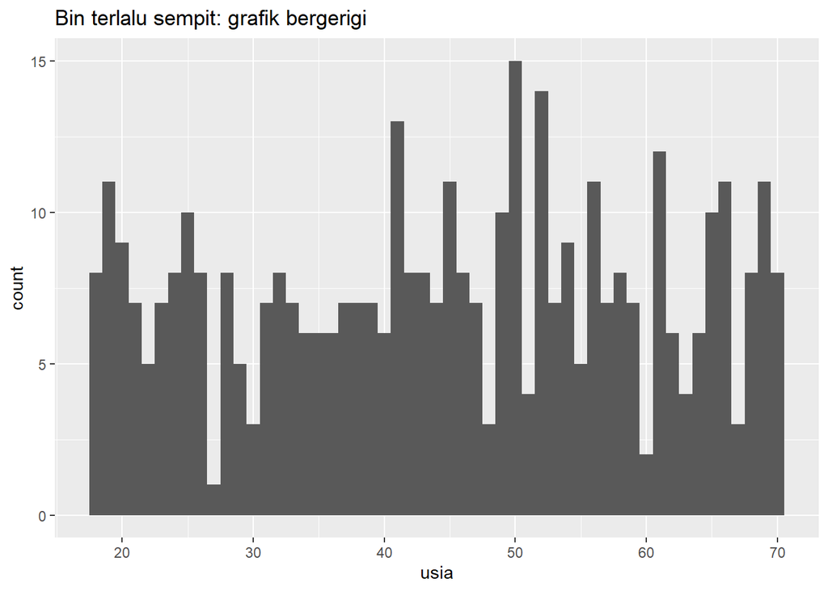

```r
ggplot(data_raw, aes(x = usia)) +
  geom_histogram(binwidth = 1) +
  labs(title = "Bin terlalu sempit: grafik bergerigi")
```

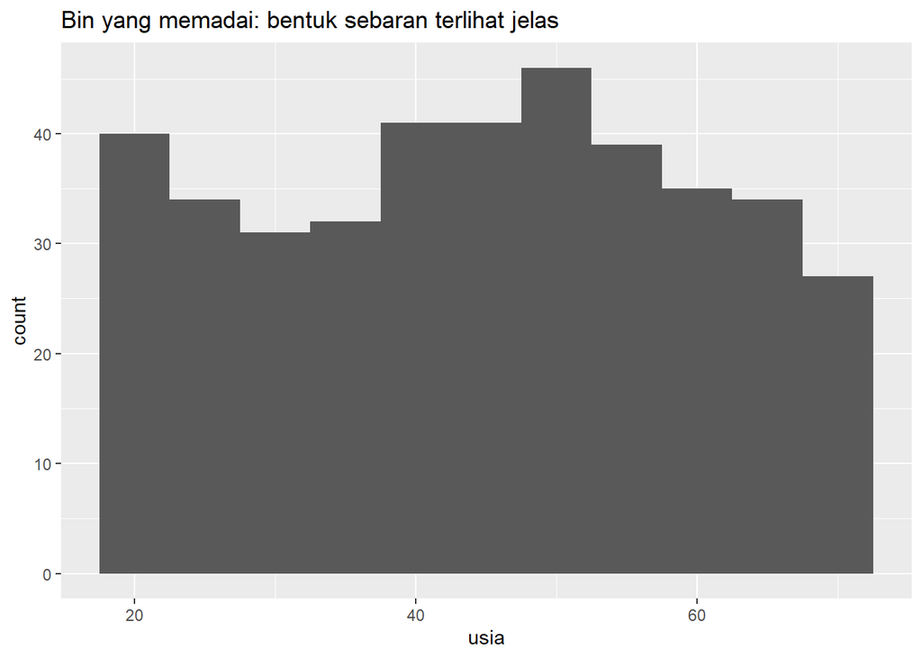

[output not shown]

```r
ggplot(data_raw, aes(x = usia)) +
  geom_histogram(binwidth = 5) +
  labs(title = "Bin yang memadai: bentuk sebaran terlihat jelas")
```

**Praktik yang baik:** coba beberapa nilai sebelum menyimpulkan bentuk distribusi.

# 11. Bivariate: Categorical × Numerical

Ini adalah pola yang **sangat penting untuk PAI**.

Pertanyaan:

> Apakah usia peserta yang pernah klaim berbeda dari peserta yang belum klaim?

Gunakan boxplot.

```r
ggplot(
  data_raw,
  aes(x = status_klaim, y = usia)
) +
  geom_boxplot()
```

[output not shown]

Logika pemilihannya:

**status klaim = kategorikal**

**usia = numerik**

→ **boxplot**

### Cara membaca

Bandingkan:

- posisi median;
- lebar/tinggi box;
- penyebaran;
- kemungkinan outlier.

### Pola jawaban

> Secara visual, kelompok [A] memiliki median usia yang lebih tinggi/rendah dibandingkan kelompok [B]. Penyebaran usia kedua kelompok terlihat [serupa/berbeda].

Hindari kalimat:

> “Usia menyebabkan seseorang melakukan klaim.”

Grafik hanya menunjukkan **pola/perbedaan**, bukan sebab-akibat.

## 11.1 Mengapa Boxplot, Bukan Bar Rata-rata?

Bar rata-rata hanya menampilkan **satu angka** per kelompok. Dua kelompok bisa memiliki rata-rata yang sama tetapi sebaran yang sangat berbeda.

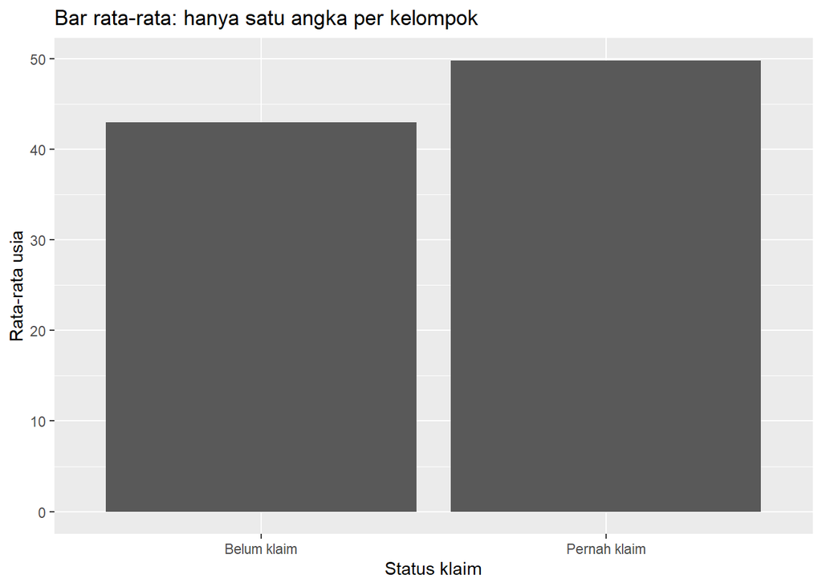

```r
data_raw %>%
  group_by(status_klaim) %>%
  summarise(rata_usia = mean(usia)) %>%
  ggplot(aes(x = status_klaim, y = rata_usia)) +
  geom_col() +
  labs(title = "Bar rata-rata: hanya satu angka per kelompok",
       x = "Status klaim", y = "Rata-rata usia")
```

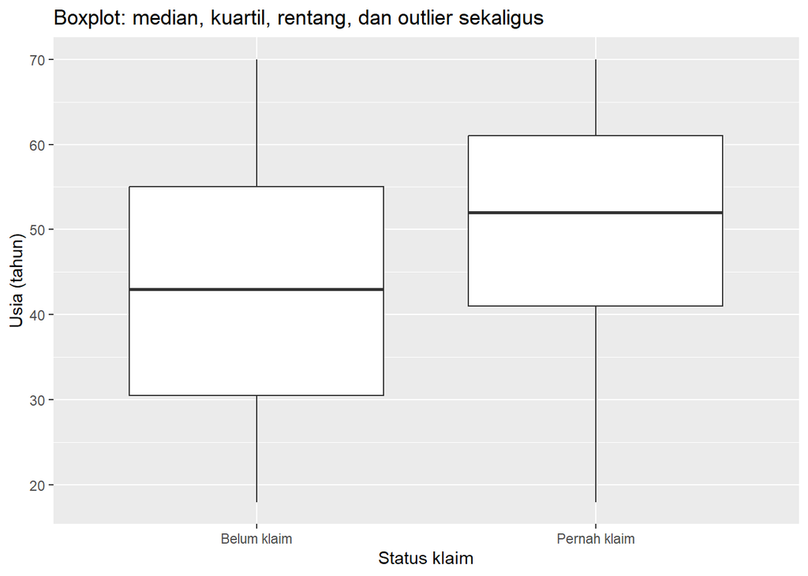

```r
ggplot(data_raw, aes(x = status_klaim, y = usia)) +
  geom_boxplot() +
  labs(title = "Boxplot: median, kuartil, rentang, dan outlier sekaligus",
       x = "Status klaim", y = "Usia (tahun)")
```

Perbedaan antar kelompok menjadi meyakinkan bila **kotaknya hampir tidak bertumpang tindih**. Bila kotaknya sangat bertumpang tindih, sebaiknya tulis bahwa perbedaan belum terlihat jelas.

## 11.2 Violin Plot

Violin plot menggambarkan bentuk kepadatan data secara penuh, seperti density plot yang dicerminkan.

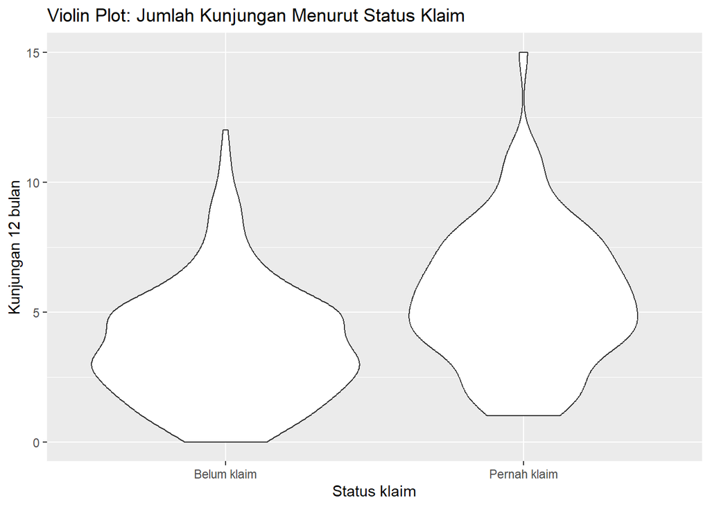

```r
ggplot(data_raw, aes(x = status_klaim, y = kunjungan_12_bulan)) +
  geom_violin() +
  labs(title = "Violin Plot: Jumlah Kunjungan Menurut Status Klaim",
       x = "Status klaim", y = "Kunjungan 12 bulan")
```

Kombinasi yang baik adalah violin ditambah boxplot kecil di dalamnya:

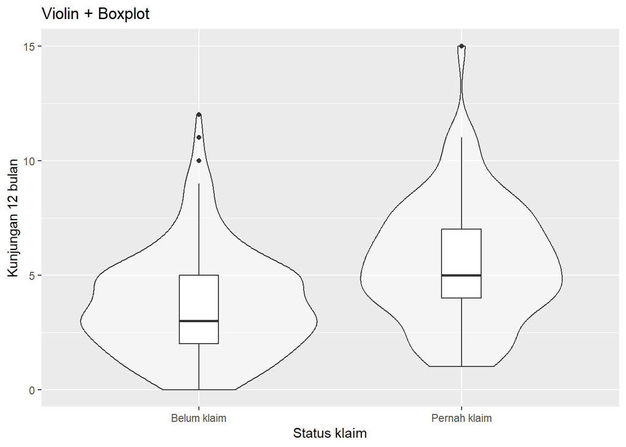

```r
ggplot(data_raw, aes(x = status_klaim, y = kunjungan_12_bulan)) +
  geom_violin(alpha = 0.5) +
  geom_boxplot(width = 0.15) +
  labs(title = "Violin + Boxplot",
       x = "Status klaim", y = "Kunjungan 12 bulan")
```

Violin menunjukkan bentuk distribusi; boxplot kecil di dalamnya menegaskan letak median dan kuartil.

## 11.3 Grouped Summary

Kadang klien meminta satu angka ringkasan per kelompok. Untuk itu ringkas dulu dengan `dplyr`.

```r
ringkasan_klaim <- data_raw %>%
  group_by(status_klaim) %>%
  summarise(
    jumlah          = n(),
    rata_usia       = mean(usia),
    median_kunjungan = median(kunjungan_12_bulan),
    rata_waktu_tunggu = mean(waktu_tunggu_hari)
  )

ringkasan_klaim
```

```
## # A tibble: 2 × 5
##   status_klaim jumlah rata_usia median_kunjungan rata_waktu_tunggu
##   <chr>         <int>     <dbl>            <int>             <dbl>
## 1 Belum klaim     311      43.0                3              3.53
## 2 Pernah klaim     89      49.8                5              3.90
```

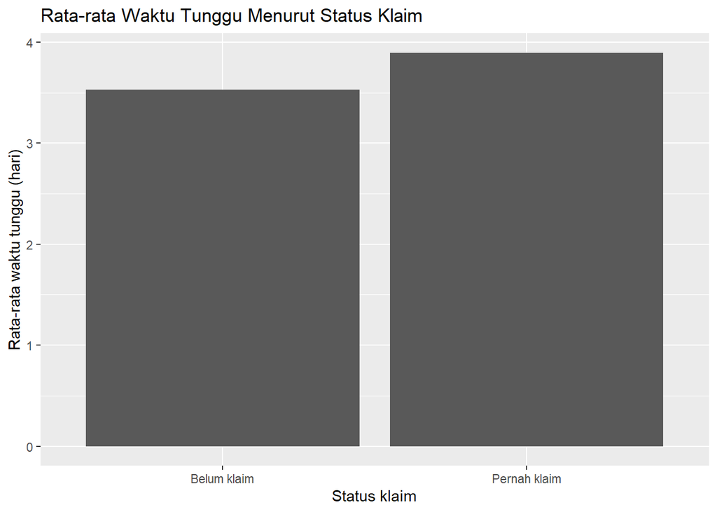

```r
ggplot(ringkasan_klaim, aes(x = status_klaim, y = rata_waktu_tunggu)) +
  geom_col() +
  labs(title = "Rata-rata Waktu Tunggu Menurut Status Klaim",
       x = "Status klaim", y = "Rata-rata waktu tunggu (hari)")
```

### Ringkasan perbandingan

| Grafik | Kelebihan | Kekurangan |
| --- | --- | --- |
| Boxplot | Ringkas, mudah dibandingkan untuk banyak kelompok | Bentuk distribusi tidak terlihat (bimodal tersembunyi) |
| Violin | Bentuk distribusi terlihat utuh | Butuh cukup banyak data agar bentuknya bermakna |
| Bar ringkasan | Paling mudah dibaca awam | Menyembunyikan sebaran |